# Text Mining Trump Speeches with R

## K-means clustering

The k-means clustering method will attempt to cluster words into a specified number of groups (in this case 2), such that the sum of squared distances between individual words and one of the group centers. You can change the number of groups you seek by changing the number specified within the kmeans() command. Run the install.packages(“fpc”) command if you have not done so already above and attach both the fpc and cluster library

```r
library(fpc)
library(cluster)
```

Once the libraries are loaded, remove sparse terms from your matrix and run the term distance analysis

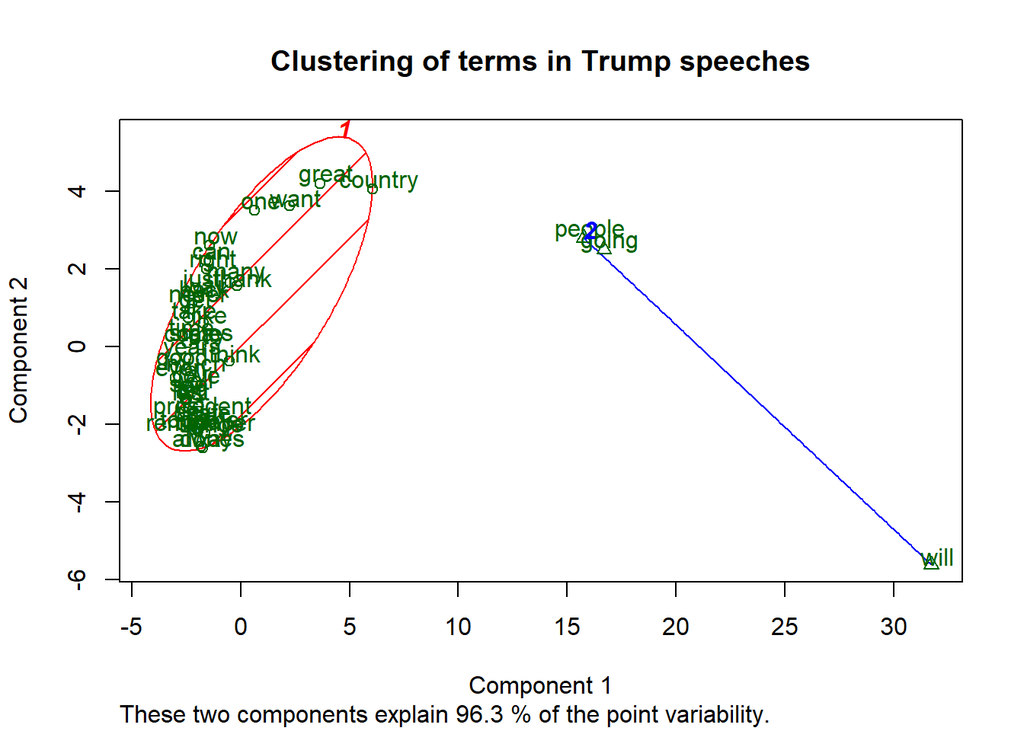

```r
dtms <- removeSparseTerms(dtm, 0.15) # Prepare the data (max 15% empty space)
d <- dist(t(dtms), method="euclidian")
kfit <- kmeans(d, 2)
clusplot(as.matrix(d), kfit$cluster, color=T, shade=T, labels=2, lines=0,
         main = "Clustering of terms in Trump speeches")
```

# Experiment, Reuse and Enjoy

Good job! You made it to the end :) To learn more about text mining specifically, or data mining in general, there is an [online course](https://togaware.com/onepager/) by Graham Williams, author of [Data Mining with Rattle and R: The Art of Excavating Data for Knowledge Discovery](https://www.amazon.com/gp/product/1441998896/ref=as_li_qf_sp_asin_tl?ie=UTF8&tag=togaware-20&linkCode=as2&camp=217145&creative=399373&creativeASIN=1441998896). Quite a lot of the material above was initially derived from his “Text Mining” segment.